> **Tip**: Welcome to the Investigate a Dataset project! You will find tips in quoted sections like this to help organize your approach to your investigation. Once you complete this project, remove these **Tip** sections from your report before submission. First things first, you might want to double-click this Markdown cell and change the title so that it reflects your dataset and investigation.

# Project: Investigate The Soccer Dataset

- Introduction
- Data Wrangling
- Exploratory Data Analysis
- Conclusions

## Introduction

### Dataset Description

> **Tip**: In this section of the report, provide a brief introduction to the dataset you've selected/downloaded for analysis. Read through the description available on the homepage-links present [here](https://docs.google.com/document/d/e/2PACX-1vTlVmknRRnfy_4eTrjw5hYGaiQim5ctr9naaRd4V9du2B5bxpd8FEH3KtDgp8qVekw7Cj1GLk1IXdZi/pub?embedded=True). List all column names in each table, and their significance. In case of multiple tables, describe the relationship between tables.

### Question(s) for Analysis

> **Tip**: Clearly state one or more questions that you plan on exploring over the course of the report. You will address these questions in the **data analysis** and **conclusion** sections. Try to build your report around the analysis of at least one dependent variable and three independent variables. If you're not sure what questions to ask, then make sure you familiarize yourself with the dataset, its variables and the dataset context for ideas of what to explore.

> **Tip**: Once you start coding, use NumPy arrays, Pandas Series, and DataFrames where appropriate rather than Python lists and dictionaries. Also, **use good coding practices**, such as, define and use functions to avoid repetitive code. Use appropriate comments within the code cells, explanation in the mark-down cells, and meaningful variable names.

```python
import sqlite3
import pandas as pd
import numpy as np
import matplotlib.pyplot as plt
import seaborn as sns
%matplotlib inline
```

```python
connection=sqlite3.connect("database.sqlite")
```

```python
cursor=connection.cursor()
```

```python
query_country='Select * from Country'
query_league='Select * from League'
query_match='Select * from Match'
query_player='Select * from Player'
query_player_attributes='Select * from player_Attributes'
query_team='Select * from Team'
query_team_attributes='Select * from Team_Attributes'
```

## Questions:

1. **Did defensive improvments help teams lose less games at home over the years?**
2. **How do players' performance change over time?**

## Data Wrangling

> **Tip**: In this section of the report, you will load in the data, check for cleanliness, and then trim and clean your dataset for analysis. Make sure that you **document your data cleaning steps in mark-down cells precisely and justify your cleaning decisions.**

### General Properties

> **Tip**: You should *not* perform too many operations in each cell. Create cells freely to explore your data. One option that you can take with this project is to do a lot of explorations in an initial notebook. These don't have to be organized, but make sure you use enough comments to understand the purpose of each code cell. Then, after you're done with your analysis, create a duplicate notebook where you will trim the excess and organize your steps so that you have a flowing, cohesive report.

```python
# Load your data and print out a few lines. Perform operations to inspect data
#   types and look for instances of missing or possibly errant data.
df_country=pd.read_sql_query(query_country,connection)
df_league=pd.read_sql_query(query_league,connection)
df_match=pd.read_sql_query(query_match,connection)
df_player=pd.read_sql_query(query_player,connection)
df_player_att=pd.read_sql_query(query_player_attributes,connection)
df_team=pd.read_sql_query(query_team,connection)
df_team_att=pd.read_sql_query(query_team_attributes,connection)
```

```python
df_team_att=pd.read_sql_query(query_team_attributes,connection)
df_team=pd.read_sql_query(query_team,connection)
df_match=pd.read_sql_query(query_match,connection)
```

```python
df_team_att.head()
```

|  | id | team_fifa_api_id | team_api_id | date | buildUpPlaySpeed | buildUpPlaySpeedClass | buildUpPlayDribbling | buildUpPlayDribblingClass | buildUpPlayPassing | buildUpPlayPassingClass | ... | chanceCreationShooting | chanceCreationShootingClass | chanceCreationPositioningClass | defencePressure | defencePressureClass | defenceAggression | defenceAggressionClass | defenceTeamWidth | defenceTeamWidthClass | defenceDefenderLineClass |
| --- | --- | --- | --- | --- | --- | --- | --- | --- | --- | --- | --- | --- | --- | --- | --- | --- | --- | --- | --- | --- | --- |
| 0 | 1 | 434 | 9930 | 2010-02-22 00:00:00 | 60 | Balanced | NaN | Little | 50 | Mixed | ... | 55 | Normal | Organised | 50 | Medium | 55 | Press | 45 | Normal | Cover |
| 1 | 2 | 434 | 9930 | 2014-09-19 00:00:00 | 52 | Balanced | 48.0 | Normal | 56 | Mixed | ... | 64 | Normal | Organised | 47 | Medium | 44 | Press | 54 | Normal | Cover |
| 2 | 3 | 434 | 9930 | 2015-09-10 00:00:00 | 47 | Balanced | 41.0 | Normal | 54 | Mixed | ... | 64 | Normal | Organised | 47 | Medium | 44 | Press | 54 | Normal | Cover |
| 3 | 4 | 77 | 8485 | 2010-02-22 00:00:00 | 70 | Fast | NaN | Little | 70 | Long | ... | 70 | Lots | Organised | 60 | Medium | 70 | Double | 70 | Wide | Cover |
| 4 | 5 | 77 | 8485 | 2011-02-22 00:00:00 | 47 | Balanced | NaN | Little | 52 | Mixed | ... | 52 | Normal | Organised | 47 | Medium | 47 | Press | 52 | Normal | Cover |

5 rows × 25 columns

```python
df_team_att.describe()
```

|  | id | team_fifa_api_id | team_api_id | buildUpPlaySpeed | buildUpPlayDribbling | buildUpPlayPassing | chanceCreationPassing | chanceCreationCrossing | chanceCreationShooting | defencePressure | defenceAggression | defenceTeamWidth |
| --- | --- | --- | --- | --- | --- | --- | --- | --- | --- | --- | --- | --- |
| count | 1458.000000 | 1458.000000 | 1458.000000 | 1458.000000 | 489.000000 | 1458.000000 | 1458.000000 | 1458.000000 | 1458.000000 | 1458.000000 | 1458.000000 | 1458.000000 |
| mean | 729.500000 | 17706.982167 | 9995.727023 | 52.462277 | 48.607362 | 48.490398 | 52.165295 | 53.731824 | 53.969136 | 46.017147 | 49.251029 | 52.185871 |
| std | 421.032659 | 39179.857739 | 13264.869900 | 11.545869 | 9.678290 | 10.896101 | 10.360793 | 11.086796 | 10.327566 | 10.227225 | 9.738028 | 9.574712 |
| min | 1.000000 | 1.000000 | 1601.000000 | 20.000000 | 24.000000 | 20.000000 | 21.000000 | 20.000000 | 22.000000 | 23.000000 | 24.000000 | 29.000000 |
| 25% | 365.250000 | 110.000000 | 8457.750000 | 45.000000 | 42.000000 | 40.000000 | 46.000000 | 47.000000 | 48.000000 | 39.000000 | 44.000000 | 47.000000 |
| 50% | 729.500000 | 485.000000 | 8674.000000 | 52.000000 | 49.000000 | 50.000000 | 52.000000 | 53.000000 | 53.000000 | 45.000000 | 48.000000 | 52.000000 |
| 75% | 1093.750000 | 1900.000000 | 9904.000000 | 62.000000 | 55.000000 | 55.000000 | 59.000000 | 62.000000 | 61.000000 | 51.000000 | 55.000000 | 58.000000 |
| max | 1458.000000 | 112513.000000 | 274581.000000 | 80.000000 | 77.000000 | 80.000000 | 80.000000 | 80.000000 | 80.000000 | 72.000000 | 72.000000 | 73.000000 |

```python
df_team_att.shape
```

```
(1458, 25)
```

```python
df_match.head()
```

|  | id | country_id | league_id | season | stage | date | match_api_id | home_team_api_id | away_team_api_id | home_team_goal | ... | SJA | VCH | VCD | VCA | GBH | GBD | GBA | BSH | BSD | BSA |
| --- | --- | --- | --- | --- | --- | --- | --- | --- | --- | --- | --- | --- | --- | --- | --- | --- | --- | --- | --- | --- | --- |
| 0 | 1 | 1 | 1 | 2008/2009 | 1 | 2008-08-17 00:00:00 | 492473 | 9987 | 9993 | 1 | ... | 4.00 | 1.65 | 3.40 | 4.50 | 1.78 | 3.25 | 4.00 | 1.73 | 3.40 | 4.20 |
| 1 | 2 | 1 | 1 | 2008/2009 | 1 | 2008-08-16 00:00:00 | 492474 | 10000 | 9994 | 0 | ... | 3.80 | 2.00 | 3.25 | 3.25 | 1.85 | 3.25 | 3.75 | 1.91 | 3.25 | 3.60 |
| 2 | 3 | 1 | 1 | 2008/2009 | 1 | 2008-08-16 00:00:00 | 492475 | 9984 | 8635 | 0 | ... | 2.50 | 2.35 | 3.25 | 2.65 | 2.50 | 3.20 | 2.50 | 2.30 | 3.20 | 2.75 |
| 3 | 4 | 1 | 1 | 2008/2009 | 1 | 2008-08-17 00:00:00 | 492476 | 9991 | 9998 | 5 | ... | 7.50 | 1.45 | 3.75 | 6.50 | 1.50 | 3.75 | 5.50 | 1.44 | 3.75 | 6.50 |
| 4 | 5 | 1 | 1 | 2008/2009 | 1 | 2008-08-16 00:00:00 | 492477 | 7947 | 9985 | 1 | ... | 1.73 | 4.50 | 3.40 | 1.65 | 4.50 | 3.50 | 1.65 | 4.75 | 3.30 | 1.67 |

5 rows × 115 columns

```python
df_match.describe()
```

|  | id | country_id | league_id | stage | match_api_id | home_team_api_id | away_team_api_id | home_team_goal | away_team_goal | home_player_X1 | ... | SJA | VCH | VCD | VCA | GBH | GBD | GBA | BSH | BSD | BSA |
| --- | --- | --- | --- | --- | --- | --- | --- | --- | --- | --- | --- | --- | --- | --- | --- | --- | --- | --- | --- | --- | --- |
| count | 25979.000000 | 25979.000000 | 25979.000000 | 25979.000000 | 2.597900e+04 | 25979.000000 | 25979.000000 | 25979.000000 | 25979.000000 | 24158.000000 | ... | 17097.000000 | 22568.000000 | 22568.000000 | 22568.000000 | 14162.000000 | 14162.000000 | 14162.000000 | 14161.000000 | 14161.000000 | 14161.000000 |
| mean | 12990.000000 | 11738.630317 | 11738.630317 | 18.242773 | 1.195429e+06 | 9984.371993 | 9984.475115 | 1.544594 | 1.160938 | 0.999586 | ... | 4.622343 | 2.668107 | 3.899048 | 4.840281 | 2.498764 | 3.648189 | 4.353097 | 2.497894 | 3.660742 | 4.405663 |
| std | 7499.635658 | 7553.936759 | 7553.936759 | 10.407354 | 4.946279e+05 | 14087.453758 | 14087.445135 | 1.297158 | 1.142110 | 0.022284 | ... | 3.632164 | 1.928753 | 1.248221 | 4.318338 | 1.489299 | 0.867440 | 3.010189 | 1.507793 | 0.868272 | 3.189814 |
| min | 1.000000 | 1.000000 | 1.000000 | 1.000000 | 4.831290e+05 | 1601.000000 | 1601.000000 | 0.000000 | 0.000000 | 0.000000 | ... | 1.100000 | 1.030000 | 1.620000 | 1.080000 | 1.050000 | 1.450000 | 1.120000 | 1.040000 | 1.330000 | 1.120000 |
| 25% | 6495.500000 | 4769.000000 | 4769.000000 | 9.000000 | 7.684365e+05 | 8475.000000 | 8475.000000 | 1.000000 | 0.000000 | 1.000000 | ... | 2.500000 | 1.700000 | 3.300000 | 2.550000 | 1.670000 | 3.200000 | 2.500000 | 1.670000 | 3.250000 | 2.500000 |
| 50% | 12990.000000 | 10257.000000 | 10257.000000 | 18.000000 | 1.147511e+06 | 8697.000000 | 8697.000000 | 1.000000 | 1.000000 | 1.000000 | ... | 3.500000 | 2.150000 | 3.500000 | 3.500000 | 2.100000 | 3.300000 | 3.400000 | 2.100000 | 3.400000 | 3.400000 |
| 75% | 19484.500000 | 17642.000000 | 17642.000000 | 27.000000 | 1.709852e+06 | 9925.000000 | 9925.000000 | 2.000000 | 2.000000 | 1.000000 | ... | 5.250000 | 2.800000 | 4.000000 | 5.400000 | 2.650000 | 3.750000 | 5.000000 | 2.620000 | 3.750000 | 5.000000 |
| max | 25979.000000 | 24558.000000 | 24558.000000 | 38.000000 | 2.216672e+06 | 274581.000000 | 274581.000000 | 10.000000 | 9.000000 | 2.000000 | ... | 41.000000 | 36.000000 | 26.000000 | 67.000000 | 21.000000 | 11.000000 | 34.000000 | 17.000000 | 13.000000 | 34.000000 |

8 rows × 105 columns

```python
df_match.shape
```

```
(25979, 115)
```

### Data Cleaning

> **Tip**: Make sure that you keep your reader informed on the steps that you are taking in your investigation. Follow every code cell, or every set of related code cells, with a markdown cell to describe to the reader what was found in the preceding cell(s). Try to make it so that the reader can then understand what they will be seeing in the following cell(s).

### Remove excessive columns from match daraframe

```python
df_match=df_match.iloc[:,:11]
```

```python
df_match.info()
```

```
<class 'pandas.core.frame.DataFrame'>
RangeIndex: 25979 entries, 0 to 25978
Data columns (total 11 columns):
 #   Column            Non-Null Count  Dtype
---  ------            --------------  -----
 0   id                25979 non-null  int64
 1   country_id        25979 non-null  int64
 2   league_id         25979 non-null  int64
 3   season            25979 non-null  object
 4   stage             25979 non-null  int64
 5   date              25979 non-null  object
 6   match_api_id      25979 non-null  int64
 7   home_team_api_id  25979 non-null  int64
 8   away_team_api_id  25979 non-null  int64
 9   home_team_goal    25979 non-null  int64
 10  away_team_goal    25979 non-null  int64
dtypes: int64(9), object(2)
memory usage: 2.2+ MB
```

```python
df_match.describe()
```

|  | id | country_id | league_id | stage | match_api_id | home_team_api_id | away_team_api_id | home_team_goal | away_team_goal |
| --- | --- | --- | --- | --- | --- | --- | --- | --- | --- |
| count | 25979.000000 | 25979.000000 | 25979.000000 | 25979.000000 | 2.597900e+04 | 25979.000000 | 25979.000000 | 25979.000000 | 25979.000000 |
| mean | 12990.000000 | 11738.630317 | 11738.630317 | 18.242773 | 1.195429e+06 | 9984.371993 | 9984.475115 | 1.544594 | 1.160938 |
| std | 7499.635658 | 7553.936759 | 7553.936759 | 10.407354 | 4.946279e+05 | 14087.453758 | 14087.445135 | 1.297158 | 1.142110 |
| min | 1.000000 | 1.000000 | 1.000000 | 1.000000 | 4.831290e+05 | 1601.000000 | 1601.000000 | 0.000000 | 0.000000 |
| 25% | 6495.500000 | 4769.000000 | 4769.000000 | 9.000000 | 7.684365e+05 | 8475.000000 | 8475.000000 | 1.000000 | 0.000000 |
| 50% | 12990.000000 | 10257.000000 | 10257.000000 | 18.000000 | 1.147511e+06 | 8697.000000 | 8697.000000 | 1.000000 | 1.000000 |
| 75% | 19484.500000 | 17642.000000 | 17642.000000 | 27.000000 | 1.709852e+06 | 9925.000000 | 9925.000000 | 2.000000 | 2.000000 |
| max | 25979.000000 | 24558.000000 | 24558.000000 | 38.000000 | 2.216672e+06 | 274581.000000 | 274581.000000 | 10.000000 | 9.000000 |

**Add home_team_win/loss/draw away_team_win_loss/draw columns**

```python
df_match['home_team_win']=np.where(df_match['home_team_goal']>df_match['away_team_goal'],1,0)
df_match['home_team_loss']=np.where(df_match['home_team_goal']<df_match['away_team_goal'],1,0)
df_match['home_team_draw']=np.where(df_match['home_team_goal']==df_match['away_team_goal'],1,0)
```

```python
df_match.head()
```

|  | id | country_id | league_id | season | stage | date | match_api_id | home_team_api_id | away_team_api_id | home_team_goal | away_team_goal | home_team_win | home_team_loss | home_team_draw |
| --- | --- | --- | --- | --- | --- | --- | --- | --- | --- | --- | --- | --- | --- | --- |
| 0 | 1 | 1 | 1 | 2008/2009 | 1 | 2008-08-17 00:00:00 | 492473 | 9987 | 9993 | 1 | 1 | 0 | 0 | 1 |
| 1 | 2 | 1 | 1 | 2008/2009 | 1 | 2008-08-16 00:00:00 | 492474 | 10000 | 9994 | 0 | 0 | 0 | 0 | 1 |
| 2 | 3 | 1 | 1 | 2008/2009 | 1 | 2008-08-16 00:00:00 | 492475 | 9984 | 8635 | 0 | 3 | 0 | 1 | 0 |
| 3 | 4 | 1 | 1 | 2008/2009 | 1 | 2008-08-17 00:00:00 | 492476 | 9991 | 9998 | 5 | 0 | 1 | 0 | 0 |
| 4 | 5 | 1 | 1 | 2008/2009 | 1 | 2008-08-16 00:00:00 | 492477 | 7947 | 9985 | 1 | 3 | 0 | 1 | 0 |

```python
df_match['away_team_win']=np.where(df_match['home_team_goal']<df_match['away_team_goal'],1,0)
df_match['away_team_loss']=np.where(df_match['home_team_goal']>df_match['away_team_goal'],1,0)
df_match['away_team_draw']=np.where(df_match['home_team_goal']==df_match['away_team_goal'],1,0)
```

convert date to pandas datetime format type

```python
date_formated_match=pd.to_datetime(df_match['date'],format="%Y/%m",exact=True)
```

```python
df_match['date']=date_formated_match
```

```python
df_match['season'].unique()
```

```
array(['2008/2009', '2009/2010', '2010/2011', '2011/2012', '2012/2013',
       '2013/2014', '2014/2015', '2015/2016'], dtype=object)
```

**Remove 2008/2009 and 2009/2010 seasons due to fact that team_att dataframe data start from 2010**

```python
df_match.query("season != '2008/2009' & season != '2009/2010'",inplace=True)
```

check if there is any duplicate in data

```python
df_match.duplicated().sum()
```

```
0
```

**clean team_att dataframe**

```python
df_team_att.info()
```

```
<class 'pandas.core.frame.DataFrame'>
RangeIndex: 1458 entries, 0 to 1457
Data columns (total 25 columns):
 #   Column                          Non-Null Count  Dtype
---  ------                          --------------  -----
 0   id                              1458 non-null   int64
 1   team_fifa_api_id                1458 non-null   int64
 2   team_api_id                     1458 non-null   int64
 3   date                            1458 non-null   object
 4   buildUpPlaySpeed                1458 non-null   int64
 5   buildUpPlaySpeedClass           1458 non-null   object
 6   buildUpPlayDribbling            489 non-null    float64
 7   buildUpPlayDribblingClass       1458 non-null   object
 8   buildUpPlayPassing              1458 non-null   int64
 9   buildUpPlayPassingClass         1458 non-null   object
```

[output cut: 17 more lines]

**Due to so many missing values of 'buildUpPlayDribbling' column, it will be removed.**

```python
df_team_att.drop(columns='buildUpPlayDribbling',inplace=True)
```

**change categorical data to ordinal data**

find column names whose values are object type

```python
column_object_names=df_team_att.select_dtypes(include=[np.object]).columns
```

```python
column_object_names
```

```
Index(['date', 'buildUpPlaySpeedClass', 'buildUpPlayDribblingClass',
       'buildUpPlayPassingClass', 'buildUpPlayPositioningClass',
       'chanceCreationPassingClass', 'chanceCreationCrossingClass',
       'chanceCreationShootingClass', 'chanceCreationPositioningClass',
       'defencePressureClass', 'defenceAggressionClass',
       'defenceTeamWidthClass', 'defenceDefenderLineClass'],
      dtype='object')
```

change values of object data columns with appropriate int values

```python
df_team_att.head()
```

|  | id | team_fifa_api_id | team_api_id | date | buildUpPlaySpeed | buildUpPlaySpeedClass | buildUpPlayDribblingClass | buildUpPlayPassing | buildUpPlayPassingClass | buildUpPlayPositioningClass | ... | chanceCreationShooting | chanceCreationShootingClass | chanceCreationPositioningClass | defencePressure | defencePressureClass | defenceAggression | defenceAggressionClass | defenceTeamWidth | defenceTeamWidthClass | defenceDefenderLineClass |
| --- | --- | --- | --- | --- | --- | --- | --- | --- | --- | --- | --- | --- | --- | --- | --- | --- | --- | --- | --- | --- | --- |
| 0 | 1 | 434 | 9930 | 2010-02-22 00:00:00 | 60 | Balanced | Little | 50 | Mixed | Organised | ... | 55 | Normal | Organised | 50 | Medium | 55 | Press | 45 | Normal | Cover |
| 1 | 2 | 434 | 9930 | 2014-09-19 00:00:00 | 52 | Balanced | Normal | 56 | Mixed | Organised | ... | 64 | Normal | Organised | 47 | Medium | 44 | Press | 54 | Normal | Cover |
| 2 | 3 | 434 | 9930 | 2015-09-10 00:00:00 | 47 | Balanced | Normal | 54 | Mixed | Organised | ... | 64 | Normal | Organised | 47 | Medium | 44 | Press | 54 | Normal | Cover |
| 3 | 4 | 77 | 8485 | 2010-02-22 00:00:00 | 70 | Fast | Little | 70 | Long | Organised | ... | 70 | Lots | Organised | 60 | Medium | 70 | Double | 70 | Wide | Cover |
| 4 | 5 | 77 | 8485 | 2011-02-22 00:00:00 | 47 | Balanced | Little | 52 | Mixed | Organised | ... | 52 | Normal | Organised | 47 | Medium | 47 | Press | 52 | Normal | Cover |

5 rows × 24 columns

```python
df_team_att['date'].value_counts()
```

```
2015-09-10 00:00:00    245
2014-09-19 00:00:00    244
2011-02-22 00:00:00    244
2013-09-20 00:00:00    242
2012-02-22 00:00:00    242
2010-02-22 00:00:00    241
Name: date, dtype: int64
```

```python
dat_formated=pd.to_datetime(df_team_att['date'],format="%Y/%m",exact=True)
```

```python
df_team_att['date']=dat_formated
```

```python
df_team_att.head()
```

|  | id | team_fifa_api_id | team_api_id | date | buildUpPlaySpeed | buildUpPlaySpeedClass | buildUpPlayDribblingClass | buildUpPlayPassing | buildUpPlayPassingClass | buildUpPlayPositioningClass | ... | chanceCreationShooting | chanceCreationShootingClass | chanceCreationPositioningClass | defencePressure | defencePressureClass | defenceAggression | defenceAggressionClass | defenceTeamWidth | defenceTeamWidthClass | defenceDefenderLineClass |
| --- | --- | --- | --- | --- | --- | --- | --- | --- | --- | --- | --- | --- | --- | --- | --- | --- | --- | --- | --- | --- | --- |
| 0 | 1 | 434 | 9930 | 2010-02-22 | 60 | Balanced | Little | 50 | Mixed | Organised | ... | 55 | Normal | Organised | 50 | Medium | 55 | Press | 45 | Normal | Cover |
| 1 | 2 | 434 | 9930 | 2014-09-19 | 52 | Balanced | Normal | 56 | Mixed | Organised | ... | 64 | Normal | Organised | 47 | Medium | 44 | Press | 54 | Normal | Cover |
| 2 | 3 | 434 | 9930 | 2015-09-10 | 47 | Balanced | Normal | 54 | Mixed | Organised | ... | 64 | Normal | Organised | 47 | Medium | 44 | Press | 54 | Normal | Cover |
| 3 | 4 | 77 | 8485 | 2010-02-22 | 70 | Fast | Little | 70 | Long | Organised | ... | 70 | Lots | Organised | 60 | Medium | 70 | Double | 70 | Wide | Cover |
| 4 | 5 | 77 | 8485 | 2011-02-22 | 47 | Balanced | Little | 52 | Mixed | Organised | ... | 52 | Normal | Organised | 47 | Medium | 47 | Press | 52 | Normal | Cover |

5 rows × 24 columns

check if there is any duplicates in data

```python
df_team_att.duplicated().sum()
```

```
0
```

**change team_fifa_api_id with teams' names using df_team dataframe**

```python
df_team.head()
```

|  | id | team_api_id | team_fifa_api_id | team_long_name | team_short_name |
| --- | --- | --- | --- | --- | --- |
| 0 | 1 | 9987 | 673.0 | KRC Genk | GEN |
| 1 | 2 | 9993 | 675.0 | Beerschot AC | BAC |
| 2 | 3 | 10000 | 15005.0 | SV Zulte-Waregem | ZUL |
| 3 | 4 | 9994 | 2007.0 | Sporting Lokeren | LOK |
| 4 | 5 | 9984 | 1750.0 | KSV Cercle Brugge | CEB |

```python
df_team_att_new=df_team_att.merge(df_team,on='team_api_id')
```

```python
df_team_att_new.shape
```

```
(1458, 28)
```

```python
df_team_att_new.drop(['id_x','id_y','team_fifa_api_id_y'],axis=1,inplace=True)
```

Modify column names that end with _x

```python
df_team_att_new.rename(columns=lambda name:name[:-2] if name[-2:]=="_x" else name)
```

|  | team_fifa_api_id | team_api_id | date | buildUpPlaySpeed | buildUpPlaySpeedClass | buildUpPlayDribblingClass | buildUpPlayPassing | buildUpPlayPassingClass | buildUpPlayPositioningClass | chanceCreationPassing | ... | chanceCreationPositioningClass | defencePressure | defencePressureClass | defenceAggression | defenceAggressionClass | defenceTeamWidth | defenceTeamWidthClass | defenceDefenderLineClass | team_long_name | team_short_name |
| --- | --- | --- | --- | --- | --- | --- | --- | --- | --- | --- | --- | --- | --- | --- | --- | --- | --- | --- | --- | --- | --- |
| 0 | 434 | 9930 | 2010-02-22 | 60 | Balanced | Little | 50 | Mixed | Organised | 60 | ... | Organised | 50 | Medium | 55 | Press | 45 | Normal | Cover | FC Aarau | AAR |
| 1 | 434 | 9930 | 2014-09-19 | 52 | Balanced | Normal | 56 | Mixed | Organised | 54 | ... | Organised | 47 | Medium | 44 | Press | 54 | Normal | Cover | FC Aarau | AAR |
| 2 | 434 | 9930 | 2015-09-10 | 47 | Balanced | Normal | 54 | Mixed | Organised | 54 | ... | Organised | 47 | Medium | 44 | Press | 54 | Normal | Cover | FC Aarau | AAR |
| 3 | 77 | 8485 | 2010-02-22 | 70 | Fast | Little | 70 | Long | Organised | 70 | ... | Organised | 60 | Medium | 70 | Double | 70 | Wide | Cover | Aberdeen | ABE |
| 4 | 77 | 8485 | 2011-02-22 | 47 | Balanced | Little | 52 | Mixed | Organised | 53 | ... | Organised | 47 | Medium | 47 | Press | 52 | Normal | Cover | Aberdeen | ABE |
| ... | ... | ... | ... | ... | ... | ... | ... | ... | ... | ... | ... | ... | ... | ... | ... | ... | ... | ... | ... | ... | ... |
| 1453 | 15005 | 10000 | 2011-02-22 | 52 | Balanced | Little | 52 | Mixed | Organised | 52 | ... | Organised | 46 | Medium | 48 | Press | 53 | Normal | Cover | SV Zulte-Waregem | ZUL |
| 1454 | 15005 | 10000 | 2012-02-22 | 54 | Balanced | Little | 51 | Mixed | Organised | 47 | ... | Organised | 44 | Medium | 55 | Press | 53 | Normal | Cover | SV Zulte-Waregem | ZUL |
| 1455 | 15005 | 10000 | 2013-09-20 | 54 | Balanced | Little | 51 | Mixed | Organised | 47 | ... | Organised | 44 | Medium | 58 | Press | 37 | Normal | Cover | SV Zulte-Waregem | ZUL |
| 1456 | 15005 | 10000 | 2014-09-19 | 54 | Balanced | Normal | 51 | Mixed | Organised | 47 | ... | Organised | 44 | Medium | 58 | Press | 37 | Normal | Cover | SV Zulte-Waregem | ZUL |
| 1457 | 15005 | 10000 | 2015-09-10 | 54 | Balanced | Normal | 51 | Mixed | Organised | 47 | ... | Organised | 44 | Medium | 58 | Press | 37 | Normal | Cover | SV Zulte-Waregem | ZUL |

1458 rows × 25 columns

**Choose defensive improvment attributes**

```python
defensive_impr_atts=[ 'defencePressure', 'defenceAggression','defenceTeamWidth']
```

Find means of each attribute for each team

```python
mean_team_def_atts=df_team_att_new.groupby(['team_long_name','date'])[defensive_impr_atts].mean()
```

```python
mean_team_def_atts
```

| team_long_name | date | defencePressure | defenceAggression | defenceTeamWidth |
| --- | --- | --- | --- | --- |
| 1. FC Kaiserslautern | 2010-02-22 | 70 | 70 | 70 |
|  | 2011-02-22 | 38 | 48 | 53 |
|  | 2012-02-22 | 37 | 51 | 53 |
|  | 2013-09-20 | 48 | 50 | 53 |
|  | 2014-09-19 | 47 | 47 | 49 |
| ... | ... | ... | ... | ... |
| Śląsk Wrocław | 2011-02-22 | 48 | 47 | 51 |
|  | 2012-02-22 | 24 | 24 | 39 |
|  | 2013-09-20 | 30 | 30 | 40 |
|  | 2014-09-19 | 37 | 37 | 39 |
|  | 2015-09-10 | 45 | 55 | 39 |

1450 rows × 3 columns

Find covariance matrix

```python
mean_team_def_atts.cov()
```

|  | defencePressure | defenceAggression | defenceTeamWidth |
| --- | --- | --- | --- |
| defencePressure | 104.606669 | 41.829790 | 50.212692 |
| defenceAggression | 41.829790 | 94.642546 | 22.861977 |
| defenceTeamWidth | 50.212692 | 22.861977 | 91.876428 |

find total mean of all defensive attributes of all teams per year

```python
mean_team_def_atts["total_defensive_performance"]=mean_team_def_atts.mean(axis=1)
```

```python
mean_team_def_atts
```

| team_long_name | date | defencePressure | defenceAggression | defenceTeamWidth | total_defensive_performance |
| --- | --- | --- | --- | --- | --- |
| 1. FC Kaiserslautern | 2010-02-22 | 70 | 70 | 70 | 70.000000 |
|  | 2011-02-22 | 38 | 48 | 53 | 46.333333 |
|  | 2012-02-22 | 37 | 51 | 53 | 47.000000 |
|  | 2013-09-20 | 48 | 50 | 53 | 50.333333 |
|  | 2014-09-19 | 47 | 47 | 49 | 47.666667 |
| ... | ... | ... | ... | ... | ... |
| Śląsk Wrocław | 2011-02-22 | 48 | 47 | 51 | 48.666667 |
|  | 2012-02-22 | 24 | 24 | 39 | 29.000000 |
|  | 2013-09-20 | 30 | 30 | 40 | 33.333333 |
|  | 2014-09-19 | 37 | 37 | 39 | 37.666667 |
|  | 2015-09-10 | 45 | 55 | 39 | 46.333333 |

1450 rows × 4 columns

calculate year to year total_defensive_performace for each team

```python
mean_team_def_atts['pct_change']=mean_team_def_atts.groupby('team_long_name')['total_defensive_performance'].pct_change()
```

```python
mean_team_def_atts.head(10)
```

| team_long_name | date | defencePressure | defenceAggression | defenceTeamWidth | total_defensive_performance | pct_change |
| --- | --- | --- | --- | --- | --- | --- |
| 1. FC Kaiserslautern | 2010-02-22 | 70 | 70 | 70 | 70.000000 | NaN |
|  | 2011-02-22 | 38 | 48 | 53 | 46.333333 | -0.338095 |
|  | 2012-02-22 | 37 | 51 | 53 | 47.000000 | 0.014388 |
|  | 2013-09-20 | 48 | 50 | 53 | 50.333333 | 0.070922 |
|  | 2014-09-19 | 47 | 47 | 49 | 47.666667 | -0.052980 |
|  | 2015-09-10 | 41 | 51 | 53 | 48.333333 | 0.013986 |
| 1. FC Köln | 2010-02-22 | 45 | 55 | 70 | 56.666667 | NaN |
|  | 2011-02-22 | 40 | 40 | 56 | 45.333333 | -0.200000 |
|  | 2012-02-22 | 43 | 55 | 67 | 55.000000 | 0.213235 |
|  | 2013-09-20 | 43 | 55 | 67 | 55.000000 | 0.000000 |

calculate sum of pct_change to see what teams are most imporved over the years defencively

```python
teams_improvements_def_overall=mean_team_def_atts.groupby('team_long_name')['pct_change'].sum()
```

**Choose top ten most imporved teams defencivly**

```python
most_improved_teams=teams_improvements_def_overall.sort_values(ascending=False).index[:10]
```

Dependent variable:losses obtained at home per year per team

```python
df_match.head()
```

|  | id | country_id | league_id | season | stage | date | match_api_id | home_team_api_id | away_team_api_id | home_team_goal | away_team_goal | home_team_win | home_team_loss | home_team_draw | away_team_win | away_team_loss | away_team_draw |
| --- | --- | --- | --- | --- | --- | --- | --- | --- | --- | --- | --- | --- | --- | --- | --- | --- | --- |
| 516 | 517 | 1 | 1 | 2010/2011 | 1 | 2010-07-31 | 838467 | 9997 | 9989 | 1 | 0 | 1 | 0 | 0 | 0 | 1 | 0 |
| 517 | 518 | 1 | 1 | 2010/2011 | 1 | 2010-07-31 | 838468 | 8571 | 8342 | 1 | 0 | 1 | 0 | 0 | 0 | 1 | 0 |
| 518 | 519 | 1 | 1 | 2010/2011 | 1 | 2010-07-31 | 838469 | 8203 | 9994 | 2 | 0 | 1 | 0 | 0 | 0 | 1 | 0 |
| 519 | 520 | 1 | 1 | 2010/2011 | 1 | 2010-07-31 | 838472 | 10001 | 9991 | 0 | 1 | 0 | 1 | 0 | 1 | 0 | 0 |
| 520 | 521 | 1 | 1 | 2010/2011 | 1 | 2010-07-31 | 838473 | 8635 | 6351 | 4 | 1 | 1 | 0 | 0 | 0 | 1 | 0 |

```python
most_improved_teams
```

```
Index(['Vitesse', 'Ajax', 'SL Benfica', 'FC Porto', 'Sporting CP', 'FC Twente',
       'SC Heerenveen', 'Heracles Almelo', 'ADO Den Haag', 'Empoli'],
      dtype='object', name='team_long_name')
```

```python
team_api_ids=df_team_att_new.query("team_long_name== ['Vitesse', 'Ajax', 'SL Benfica', 'FC Porto', 'Sporting CP', 'FC Twente','SC Heerenveen', 'Heracles Almelo', 'ADO Den Haag', 'Empoli']").drop_duplicates(subset='team_long_name').loc[:,['team_api_id','team_long_name']]
```

```python
team_api_id_array=team_api_ids['team_api_id'].values
```

```python
team_api_id_array
```

```
array([10217,  8593,  9772,  8534,  9773,  9791, 10228,  9768,  8611,
        8277], dtype=int64)
```

```python
team_id_name_dict=dict(zip(team_api_id_array,most_improved_teams))
```

```python
team_id_name_dict
```

```
{10217: 'Vitesse',
 8593: 'Ajax',
 9772: 'SL Benfica',
 8534: 'FC Porto',
 9773: 'Sporting CP',
 9791: 'FC Twente',
 10228: 'SC Heerenveen',
 9768: 'Heracles Almelo',
 8611: 'ADO Den Haag',
 8277: 'Empoli'}
```

calculate team losses for each season

```python
team_loss_per_season=df_match.groupby(['season','home_team_api_id'])['home_team_loss'].sum()
```

```python
team_loss_per_season_df=pd.DataFrame(team_loss_per_season)
```

```python
team_loss_per_season_df
```

| season | home_team_api_id | home_team_loss |
| --- | --- | --- |
| 2010/2011 | 1601 | 4 |
|  | 1957 | 2 |
|  | 2033 | 3 |
|  | 2182 | 1 |
|  | 2183 | 5 |
| ... | ... | ... |
| 2015/2016 | 158085 | 3 |
|  | 177361 | 6 |
|  | 188163 | 10 |
|  | 208931 | 8 |
|  | 274581 | 7 |

1108 rows × 1 columns

Extract top ten teams

```python
most_imporoved_teams_losses_df=pd.DataFrame(team_loss_per_season_df.loc[:,team_api_id_array[:],:])
```

```python
most_imporoved_teams_losses_df.index.names
```

```
FrozenList(['season', 'home_team_api_id'])
```

```python
most_improved_teams_loss_year_to_year=most_imporoved_teams_losses_df.pivot_table(values="home_team_loss",index="home_team_api_id",columns='season')
```

```python
most_improved_teams_loss_year_to_year.rename(mapper=team_id_name_dict,axis=0,inplace=True)
```

```python
most_improved_teams_loss_year_to_year
```

| season home_team_api_id | 2010/2011 | 2011/2012 | 2012/2013 | 2013/2014 | 2014/2015 | 2015/2016 |
| --- | --- | --- | --- | --- | --- | --- |
| Empoli | 5.0 | 4.0 | 2.0 | 3.0 | 1.0 | 6.0 |
| FC Porto | NaN | NaN | NaN | NaN | 5.0 | 6.0 |
| Ajax | 2.0 | 1.0 | 1.0 | 1.0 | 2.0 | 1.0 |
| ADO Den Haag | 1.0 | 4.0 | 3.0 | 0.0 | 5.0 | 5.0 |
| Heracles Almelo | 4.0 | 1.0 | 4.0 | 1.0 | 0.0 | 1.0 |
| SL Benfica | 2.0 | 1.0 | 0.0 | 0.0 | 0.0 | 2.0 |
| Sporting CP | 0.0 | 0.0 | 0.0 | 1.0 | 1.0 | 3.0 |
| FC Twente | 2.0 | 6.0 | 5.0 | 8.0 | 8.0 | 3.0 |
| Vitesse | 4.0 | 6.0 | 5.0 | 5.0 | 5.0 | 5.0 |
| SC Heerenveen | 6.0 | 4.0 | 6.0 | 4.0 | 4.0 | 7.0 |

```python
most_improved_teams_stats=mean_team_def_atts.loc[most_improved_teams]
```

```python
most_improved_teams_stats
```

| team_long_name | date | defencePressure | defenceAggression | defenceTeamWidth | total_defensive_performance | pct_change |
| --- | --- | --- | --- | --- | --- | --- |
| Vitesse | 2010-02-22 | 30 | 30 | 30 | 30.000000 | NaN |
|  | 2011-02-22 | 55 | 60 | 64 | 59.666667 | 0.988889 |
|  | 2012-02-22 | 42 | 54 | 48 | 48.000000 | -0.195531 |
|  | 2013-09-20 | 42 | 45 | 48 | 45.000000 | -0.062500 |
|  | 2014-09-19 | 42 | 54 | 62 | 52.666667 | 0.170370 |
|  | 2015-09-10 | 60 | 58 | 62 | 60.000000 | 0.139241 |
| Ajax | 2010-02-22 | 30 | 30 | 30 | 30.000000 | NaN |
|  | 2011-02-22 | 65 | 57 | 63 | 61.666667 | 1.055556 |
|  | 2012-02-22 | 68 | 65 | 60 | 64.333333 | 0.043243 |
|  | 2013-09-20 | 68 | 65 | 50 | 61.000000 | -0.051813 |
|  | 2014-09-19 | 64 | 53 | 64 | 60.333333 | -0.010929 |
|  | 2015-09-10 | 64 | 53 | 59 | 58.666667 | -0.027624 |
| SL Benfica | 2010-02-22 | 30 | 30 | 30 | 30.000000 | NaN |
|  | 2011-02-22 | 55 | 56 | 60 | 57.000000 | 0.900000 |
|  | 2012-02-22 | 61 | 51 | 57 | 56.333333 | -0.011696 |
|  | 2013-09-20 | 60 | 58 | 57 | 58.333333 | 0.035503 |
|  | 2014-09-19 | 60 | 57 | 54 | 57.000000 | -0.022857 |
|  | 2015-09-10 | 60 | 57 | 54 | 57.000000 | 0.000000 |
| FC Porto | 2010-02-22 | 30 | 30 | 30 | 30.000000 | NaN |
|  | 2011-02-22 | 55 | 43 | 65 | 54.333333 | 0.811111 |
|  | 2012-02-22 | 61 | 49 | 60 | 56.666667 | 0.042945 |
|  | 2013-09-20 | 58 | 60 | 57 | 58.333333 | 0.029412 |
|  | 2014-09-19 | 58 | 60 | 60 | 59.333333 | 0.017143 |
|  | 2015-09-10 | 58 | 60 | 60 | 59.333333 | 0.000000 |
| Sporting CP | 2010-02-22 | 30 | 30 | 30 | 30.000000 | NaN |
|  | 2011-02-22 | 55 | 45 | 50 | 50.000000 | 0.666667 |
|  | 2012-02-22 | 52 | 49 | 54 | 51.666667 | 0.033333 |
|  | 2013-09-20 | 52 | 49 | 54 | 51.666667 | 0.000000 |
|  | 2014-09-19 | 60 | 60 | 54 | 58.000000 | 0.122581 |
|  | 2015-09-10 | 60 | 60 | 54 | 58.000000 | 0.000000 |
| FC Twente | 2010-02-22 | 30 | 30 | 30 | 30.000000 | NaN |
|  | 2011-02-22 | 61 | 59 | 54 | 58.000000 | 0.933333 |
|  | 2012-02-22 | 62 | 68 | 67 | 65.666667 | 0.132184 |
|  | 2013-09-20 | 34 | 44 | 54 | 44.000000 | -0.329949 |
|  | 2014-09-19 | 44 | 41 | 55 | 46.666667 | 0.060606 |
|  | 2015-09-10 | 44 | 41 | 55 | 46.666667 | 0.000000 |
| SC Heerenveen | 2010-02-22 | 30 | 30 | 30 | 30.000000 | NaN |
|  | 2011-02-22 | 58 | 60 | 65 | 61.000000 | 1.033333 |
|  | 2012-02-22 | 45 | 44 | 48 | 45.666667 | -0.251366 |
|  | 2013-09-20 | 46 | 44 | 48 | 46.000000 | 0.007299 |
|  | 2014-09-19 | 46 | 44 | 48 | 46.000000 | 0.000000 |
|  | 2015-09-10 | 46 | 44 | 48 | 46.000000 | 0.000000 |
| Heracles Almelo | 2010-02-22 | 30 | 30 | 30 | 30.000000 | NaN |
|  | 2011-02-22 | 36 | 66 | 34 | 45.333333 | 0.511111 |
|  | 2012-02-22 | 33 | 43 | 47 | 41.000000 | -0.095588 |
|  | 2013-09-20 | 47 | 43 | 47 | 45.666667 | 0.113821 |
|  | 2014-09-19 | 60 | 62 | 47 | 56.333333 | 0.233577 |
|  | 2015-09-10 | 60 | 62 | 47 | 56.333333 | 0.000000 |
| ADO Den Haag | 2010-02-22 | 30 | 30 | 30 | 30.000000 | NaN |
|  | 2011-02-22 | 46 | 62 | 65 | 57.666667 | 0.922222 |
|  | 2012-02-22 | 50 | 58 | 62 | 56.666667 | -0.017341 |
|  | 2013-09-20 | 50 | 58 | 52 | 53.333333 | -0.058824 |
|  | 2014-09-19 | 57 | 50 | 52 | 53.000000 | -0.006250 |
|  | 2015-09-10 | 40 | 50 | 52 | 47.333333 | -0.106918 |
| Empoli | 2010-02-22 | 30 | 30 | 30 | 30.000000 | NaN |
|  | 2011-02-22 | 45 | 45 | 47 | 45.666667 | 0.522222 |
|  | 2012-02-22 | 35 | 45 | 50 | 43.333333 | -0.051095 |
|  | 2013-09-20 | 39 | 50 | 59 | 49.333333 | 0.138462 |
|  | 2014-09-19 | 53 | 57 | 54 | 54.666667 | 0.108108 |
|  | 2015-09-10 | 46 | 66 | 48 | 53.333333 | -0.024390 |

## Exploratory Data Analysis

## Did defensive improvments help a team to lose less games at home?

**Plot team losses per season at home"**

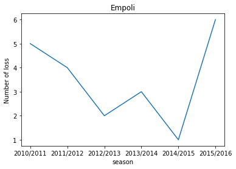

```python
most_improved_teams_loss_year_to_year.iloc[0,:].plot(ylabel='Number of loss',title='Empoli')
```

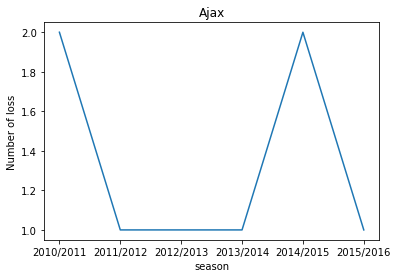

```python
most_improved_teams_loss_year_to_year.iloc[2,:].plot(ylabel='Number of loss',title='Ajax')
```

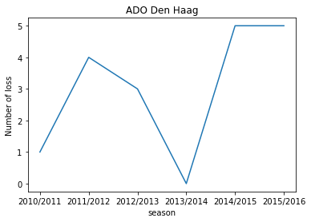

```python
most_improved_teams_loss_year_to_year.iloc[3,:].plot(ylabel='Number of loss',title='ADO Den Haag')
```

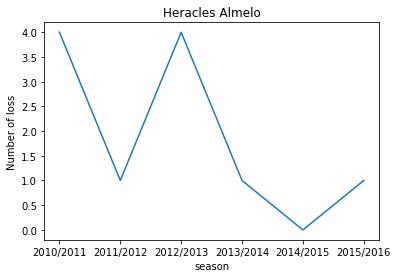

```python
most_improved_teams_loss_year_to_year.iloc[4,:].plot(ylabel='Number of loss',title='Heracles Almelo')
```

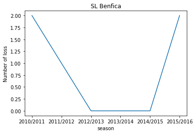

```python
most_improved_teams_loss_year_to_year.iloc[5,:].plot(ylabel='Number of loss',title='SL Benfica')
```

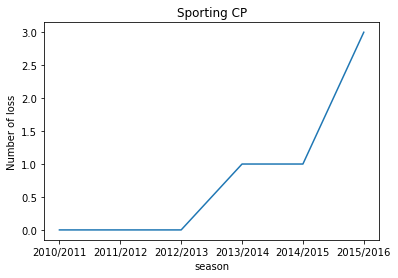

```python
most_improved_teams_loss_year_to_year.iloc[6,:].plot(ylabel='Number of loss',title='Sporting CP')
```

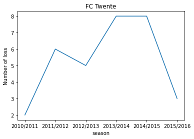

```python
most_improved_teams_loss_year_to_year.iloc[7,:].plot(ylabel='Number of loss',title='FC Twente')
```

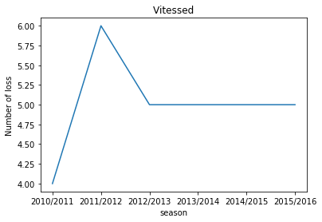

```python
most_improved_teams_loss_year_to_year.iloc[8,:].plot(ylabel='Number of loss',title='Vitessed')
```

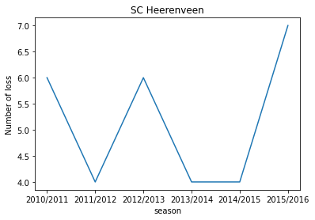

```python
most_improved_teams_loss_year_to_year.iloc[9,:].plot(ylabel='Number of loss',title='SC Heerenveen')
```

**Plot total defensive performance per team per season vs number of losses per team per season**

```python
team_id_name_dict
```

```
{10217: 'Vitesse',
 8593: 'Ajax',
 9772: 'SL Benfica',
 8534: 'FC Porto',
 9773: 'Sporting CP',
 9791: 'FC Twente',
 10228: 'SC Heerenveen',
 9768: 'Heracles Almelo',
 8611: 'ADO Den Haag',
 8277: 'Empoli'}
```

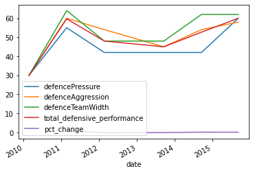

```python
most_improved_teams_stats.loc['Vitesse'].plot()
```

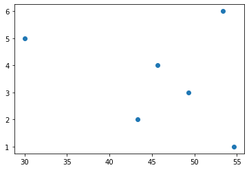

```python
plt.scatter(most_improved_teams_stats.loc['Empoli']["total_defensive_performance"],most_improved_teams_loss_year_to_year.iloc[0,:])
```

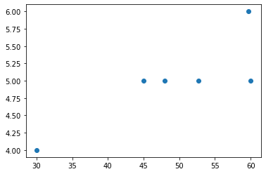

```python
plt.scatter(most_improved_teams_stats.loc['Vitesse']["total_defensive_performance"],most_improved_teams_loss_year_to_year.iloc[8,:])
```

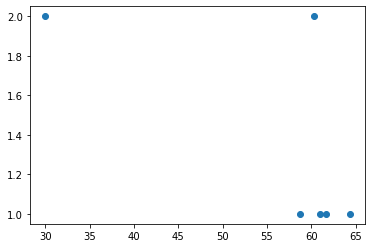

```python
plt.scatter(most_improved_teams_stats.loc['Ajax']["total_defensive_performance"],most_improved_teams_loss_year_to_year.iloc[2,:])
```

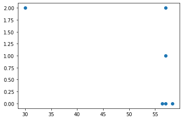

```python
plt.scatter(most_improved_teams_stats.loc['SL Benfica']["total_defensive_performance"],most_improved_teams_loss_year_to_year.iloc[5,:])
```

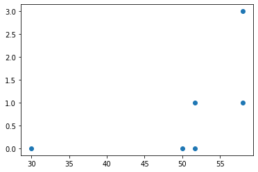

```python
plt.scatter(most_improved_teams_stats.loc['Sporting CP']["total_defensive_performance"],most_improved_teams_loss_year_to_year.iloc[6,:])
```

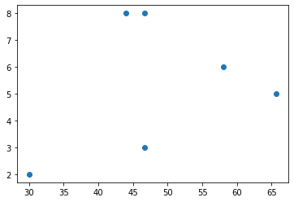

```python
plt.scatter(most_improved_teams_stats.loc['FC Twente']["total_defensive_performance"],most_improved_teams_loss_year_to_year.iloc[7,:])
```

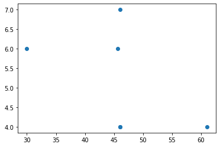

```python
plt.scatter(most_improved_teams_stats.loc['SC Heerenveen']["total_defensive_performance"],most_improved_teams_loss_year_to_year.iloc[9,:])
```

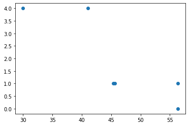

```python
plt.scatter(most_improved_teams_stats.loc['Heracles Almelo']["total_defensive_performance"],most_improved_teams_loss_year_to_year.iloc[4,:])
```

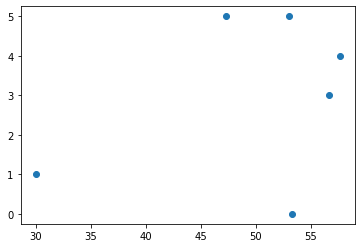

```python
plt.scatter(most_improved_teams_stats.loc['ADO Den Haag']["total_defensive_performance"],most_improved_teams_loss_year_to_year.iloc[3,:])
```

```python
most_improved_teams_loss_year_to_year.index
```

```
Index(['Empoli', 'FC Porto', 'Ajax', 'ADO Den Haag', 'Heracles Almelo',
       'SL Benfica', 'Sporting CP', 'FC Twente', 'Vitesse', 'SC Heerenveen'],
      dtype='object', name='home_team_api_id')
```

Investigate whether each independent variable will show any promises

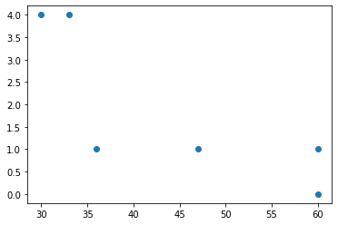

```python
plt.scatter(most_improved_teams_stats.loc['Heracles Almelo']["defencePressure"],most_improved_teams_loss_year_to_year.iloc[4,:])
```

```python
most_improved_teams_stats.columns
```

```
Index(['defencePressure', 'defenceAggression', 'defenceTeamWidth',
       'total_defensive_performance', 'pct_change'],
      dtype='object')
```

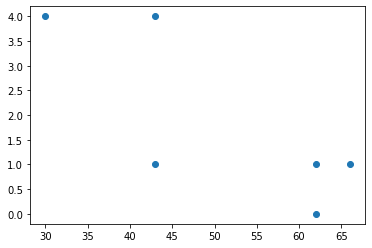

```python
plt.scatter(most_improved_teams_stats.loc['Heracles Almelo']["defenceAggression"],most_improved_teams_loss_year_to_year.iloc[4,:])
```

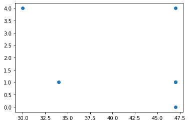

```python
plt.scatter(most_improved_teams_stats.loc['Heracles Almelo']["defenceTeamWidth"],most_improved_teams_loss_year_to_year.iloc[4,:])
```

**lets look at it from another angle**

let's see what the average total losses per season for the entire universe is and compare it to the most imporved teams

```python
universe_stat_match_loss=team_loss_per_season_df.groupby('season')['home_team_loss'].mean()
```

```python
universe_stat_match_loss
```

```
season
2010/2011    4.844086
2011/2012    4.860215
2012/2013    5.177419
2013/2014    5.126437
2014/2015    5.218085
2015/2016    5.382979
Name: home_team_loss, dtype: float64
```

```python
universe_stat_match_loss.describe()
```

```
count    6.000000
mean     5.101537
std      0.211513
min      4.844086
25%      4.926770
50%      5.151928
75%      5.207919
max      5.382979
Name: home_team_loss, dtype: float64
```

```python
most_improved_stat_summary=most_imporoved_teams_losses_df.groupby('season')['home_team_loss'].mean()
```

```python
most_improved_stat_summary
```

```
season
2010/2011    2.888889
2011/2012    3.000000
2012/2013    2.888889
2013/2014    2.555556
2014/2015    3.100000
2015/2016    3.900000
Name: home_team_loss, dtype: float64
```

```python
most_improved_stat_summary.describe()
```

```
count    6.000000
mean     3.055556
std      0.452483
min      2.555556
25%      2.888889
50%      2.944444
75%      3.075000
max      3.900000
Name: home_team_loss, dtype: float64
```

let's explore overall teams stats for every season

```python
teams_stat_summary=mean_team_def_atts.groupby('date').mean()
```

```python
teams_stat_summary
```

| date | defencePressure | defenceAggression | defenceTeamWidth | total_defensive_performance | pct_change |
| --- | --- | --- | --- | --- | --- |
| 2010-02-22 | 49.654167 | 53.258333 | 52.354167 | 51.755556 | NaN |
| 2011-02-22 | 46.231405 | 49.917355 | 53.194215 | 49.780992 | 0.038324 |
| 2012-02-22 | 44.651452 | 47.286307 | 51.933610 | 47.957123 | -0.030809 |
| 2013-09-20 | 45.203320 | 48.053942 | 52.340249 | 48.532503 | 0.013751 |
| 2014-09-19 | 44.843621 | 48.193416 | 51.691358 | 48.242798 | 0.001011 |
| 2015-09-10 | 45.662551 | 48.860082 | 51.489712 | 48.670782 | 0.011222 |

```python
teams_stat_summary.describe()
```

|  | defencePressure | defenceAggression | defenceTeamWidth | total_defensive_performance | pct_change |
| --- | --- | --- | --- | --- | --- |
| count | 6.000000 | 6.000000 | 6.000000 | 6.000000 | 5.000000 |
| mean | 46.041086 | 49.261573 | 52.167218 | 49.156626 | 0.006700 |
| std | 1.860146 | 2.147852 | 0.609859 | 1.417302 | 0.025048 |
| min | 44.651452 | 47.286307 | 51.489712 | 47.957123 | -0.030809 |
| 25% | 44.933546 | 48.088810 | 51.751921 | 48.315225 | 0.001011 |
| 50% | 45.432935 | 48.526749 | 52.136929 | 48.601643 | 0.011222 |
| 75% | 46.089192 | 49.653037 | 52.350687 | 49.503439 | 0.013751 |
| max | 49.654167 | 53.258333 | 53.194215 | 51.755556 | 0.038324 |

```python
most_improved_stats_summary=most_improved_teams_stats.groupby('date').mean()
```

```python
most_improved_stats_summary
```

| date | defencePressure | defenceAggression | defenceTeamWidth | total_defensive_performance | pct_change |
| --- | --- | --- | --- | --- | --- |
| 2010-02-22 | 30.0 | 30.0 | 30.0 | 30.000000 | NaN |
| 2011-02-22 | 53.1 | 55.3 | 56.7 | 55.033333 | 0.834444 |
| 2012-02-22 | 50.9 | 52.6 | 55.3 | 52.933333 | -0.037091 |
| 2013-09-20 | 49.6 | 51.6 | 52.6 | 51.266667 | -0.017859 |
| 2014-09-19 | 54.4 | 53.8 | 55.0 | 54.400000 | 0.067235 |
| 2015-09-10 | 53.8 | 55.1 | 53.9 | 54.266667 | -0.001969 |

```python
most_improved_stats_summary.describe()
```

|  | defencePressure | defenceAggression | defenceTeamWidth | total_defensive_performance | pct_change |
| --- | --- | --- | --- | --- | --- |
| count | 6.000000 | 6.000000 | 6.000000 | 6.000000 | 5.000000 |
| mean | 48.633333 | 49.733333 | 50.583333 | 49.650000 | 0.168952 |
| std | 9.307775 | 9.771728 | 10.177508 | 9.719802 | 0.374096 |
| min | 30.000000 | 30.000000 | 30.000000 | 30.000000 | -0.037091 |
| 25% | 49.925000 | 51.850000 | 52.925000 | 51.683333 | -0.017859 |
| 50% | 52.000000 | 53.200000 | 54.450000 | 53.600000 | -0.001969 |
| 75% | 53.625000 | 54.775000 | 55.225000 | 54.366667 | 0.067235 |
| max | 54.400000 | 55.300000 | 56.700000 | 55.033333 | 0.834444 |

```python
df_player_att.columns
```

```
Index(['id', 'player_fifa_api_id', 'player_api_id', 'date', 'overall_rating',
       'potential', 'preferred_foot', 'attacking_work_rate',
       'defensive_work_rate', 'crossing', 'finishing', 'heading_accuracy',
       'short_passing', 'volleys', 'dribbling', 'curve', 'free_kick_accuracy',
       'long_passing', 'ball_control', 'acceleration', 'sprint_speed',
       'agility', 'reactions', 'balance', 'shot_power', 'jumping', 'stamina',
       'strength', 'long_shots', 'aggression', 'interceptions', 'positioning',
       'vision', 'penalties', 'marking', 'standing_tackle', 'sliding_tackle',
       'gk_diving', 'gk_handling', 'gk_kicking', 'gk_positioning',
       'gk_reflexes'],
      dtype='object')
```

### Research Question 2 How do players' performance change over time?

Adding players' names to the player_add dataframe

```python
df_player[["player_fifa_api_id","player_name"]]
```

|  | player_fifa_api_id | player_name |
| --- | --- | --- |
| 0 | 218353 | Aaron Appindangoye |
| 1 | 189615 | Aaron Cresswell |
| 2 | 186170 | Aaron Doran |
| 3 | 140161 | Aaron Galindo |
| 4 | 17725 | Aaron Hughes |
| ... | ... | ... |
| 11055 | 2488 | Zoumana Camara |
| 11056 | 164680 | Zsolt Laczko |
| 11057 | 111191 | Zsolt Low |
| 11058 | 47058 | Zurab Khizanishvili |
| 11059 | 102359 | Zvjezdan Misimovic |

11060 rows × 2 columns

```python
players_name_dict=dict(zip(df_player['player_fifa_api_id'],df_player['player_name']))
```

```python
df_player_att['player_fifa_api_id'].replace(players_name_dict,inplace=True)
```

```python
df_player_att.rename(columns={'player_fifa_api_id':"player_name"},inplace=True)
```

```python
df_player_att.head()
```

|  | id | player_name | player_api_id | date | overall_rating | potential | preferred_foot | attacking_work_rate | defensive_work_rate | crossing | ... | vision | penalties | marking | standing_tackle | sliding_tackle | gk_diving | gk_handling | gk_kicking | gk_positioning | gk_reflexes |
| --- | --- | --- | --- | --- | --- | --- | --- | --- | --- | --- | --- | --- | --- | --- | --- | --- | --- | --- | --- | --- | --- |
| 0 | 1 | Aaron Appindangoye | 505942 | 2016-02-18 00:00:00 | 67.0 | 71.0 | right | medium | medium | 49.0 | ... | 54.0 | 48.0 | 65.0 | 69.0 | 69.0 | 6.0 | 11.0 | 10.0 | 8.0 | 8.0 |
| 1 | 2 | Aaron Appindangoye | 505942 | 2015-11-19 00:00:00 | 67.0 | 71.0 | right | medium | medium | 49.0 | ... | 54.0 | 48.0 | 65.0 | 69.0 | 69.0 | 6.0 | 11.0 | 10.0 | 8.0 | 8.0 |
| 2 | 3 | Aaron Appindangoye | 505942 | 2015-09-21 00:00:00 | 62.0 | 66.0 | right | medium | medium | 49.0 | ... | 54.0 | 48.0 | 65.0 | 66.0 | 69.0 | 6.0 | 11.0 | 10.0 | 8.0 | 8.0 |
| 3 | 4 | Aaron Appindangoye | 505942 | 2015-03-20 00:00:00 | 61.0 | 65.0 | right | medium | medium | 48.0 | ... | 53.0 | 47.0 | 62.0 | 63.0 | 66.0 | 5.0 | 10.0 | 9.0 | 7.0 | 7.0 |
| 4 | 5 | Aaron Appindangoye | 505942 | 2007-02-22 00:00:00 | 61.0 | 65.0 | right | medium | medium | 48.0 | ... | 53.0 | 47.0 | 62.0 | 63.0 | 66.0 | 5.0 | 10.0 | 9.0 | 7.0 | 7.0 |

5 rows × 42 columns

drop/fill values

```python
df_player_att.dtypes
```

```
id                       int64
player_name             object
player_api_id            int64
date                    object
overall_rating         float64
potential              float64
preferred_foot          object
attacking_work_rate     object
defensive_work_rate     object
crossing               float64
finishing              float64
heading_accuracy       float64
short_passing          float64
volleys                float64
dribbling              float64
curve                  float64
free_kick_accuracy     float64
long_passing           float64
ball_control           float64
acceleration           float64
sprint_speed           float64
agility                float64
reactions              float64
balance                float64
shot_power             float64
jumping                float64
stamina                float64
strength               float64
long_shots             float64
aggression             float64
interceptions          float64
positioning            float64
vision                 float64
penalties              float64
marking                float64
standing_tackle        float64
sliding_tackle         float64
gk_diving              float64
gk_handling            float64
gk_kicking             float64
gk_positioning         float64
gk_reflexes            float64
dtype: object
```

```python
df_player_att.info()
```

```
<class 'pandas.core.frame.DataFrame'>
RangeIndex: 183978 entries, 0 to 183977
Data columns (total 42 columns):
 #   Column               Non-Null Count   Dtype
---  ------               --------------   -----
 0   id                   183978 non-null  int64
 1   player_name          183978 non-null  object
 2   player_api_id        183978 non-null  int64
 3   date                 183978 non-null  object
 4   overall_rating       183142 non-null  float64
 5   potential            183142 non-null  float64
 6   preferred_foot       183142 non-null  object
 7   attacking_work_rate  180748 non-null  object
 8   defensive_work_rate  183142 non-null  object
 9   crossing             183142 non-null  float64
```

[output cut: 34 more lines]

```python
df_player_att.dropna(axis=0,inplace=True)
```

```python
df_player_att.drop(columns=["preferred_foot","attacking_work_rate","defensive_work_rate"],inplace=True)
```

```python
df_player_att.drop(columns=["id","player_api_id"],inplace=True)
```

```python
player_stats_grouped=df_player_att.groupby(['player_name','date']).mean()
```

```python
player_stats_grouped
```

| player_name | date | overall_rating | potential | crossing | finishing | heading_accuracy | short_passing | volleys | dribbling | curve | free_kick_accuracy | ... | vision | penalties | marking | standing_tackle | sliding_tackle | gk_diving | gk_handling | gk_kicking | gk_positioning | gk_reflexes |
| --- | --- | --- | --- | --- | --- | --- | --- | --- | --- | --- | --- | --- | --- | --- | --- | --- | --- | --- | --- | --- | --- | --- |
| Aaron Appindangoye | 2007-02-22 00:00:00 | 61.0 | 65.0 | 48.0 | 43.0 | 70.0 | 60.0 | 43.0 | 50.0 | 44.0 | 38.0 | ... | 53.0 | 47.0 | 62.0 | 63.0 | 66.0 | 5.0 | 10.0 | 9.0 | 7.0 | 7.0 |
|  | 2015-03-20 00:00:00 | 61.0 | 65.0 | 48.0 | 43.0 | 70.0 | 60.0 | 43.0 | 50.0 | 44.0 | 38.0 | ... | 53.0 | 47.0 | 62.0 | 63.0 | 66.0 | 5.0 | 10.0 | 9.0 | 7.0 | 7.0 |
|  | 2015-09-21 00:00:00 | 62.0 | 66.0 | 49.0 | 44.0 | 71.0 | 61.0 | 44.0 | 51.0 | 45.0 | 39.0 | ... | 54.0 | 48.0 | 65.0 | 66.0 | 69.0 | 6.0 | 11.0 | 10.0 | 8.0 | 8.0 |
|  | 2015-11-19 00:00:00 | 67.0 | 71.0 | 49.0 | 44.0 | 71.0 | 61.0 | 44.0 | 51.0 | 45.0 | 39.0 | ... | 54.0 | 48.0 | 65.0 | 69.0 | 69.0 | 6.0 | 11.0 | 10.0 | 8.0 | 8.0 |
|  | 2016-02-18 00:00:00 | 67.0 | 71.0 | 49.0 | 44.0 | 71.0 | 61.0 | 44.0 | 51.0 | 45.0 | 39.0 | ... | 54.0 | 48.0 | 65.0 | 69.0 | 69.0 | 6.0 | 11.0 | 10.0 | 8.0 | 8.0 |
| ... | ... | ... | ... | ... | ... | ... | ... | ... | ... | ... | ... | ... | ... | ... | ... | ... | ... | ... | ... | ... | ... | ... |
| de Oliveira Cleber Monteiro | 2012-02-22 00:00:00 | 62.0 | 62.0 | 48.0 | 48.0 | 54.0 | 65.0 | 45.0 | 47.0 | 30.0 | 48.0 | ... | 61.0 | 51.0 | 53.0 | 64.0 | 61.0 | 15.0 | 15.0 | 15.0 | 12.0 | 14.0 |
| dos Santos Fabio Junior | 2007-02-22 00:00:00 | 64.0 | 72.0 | 61.0 | 61.0 | 64.0 | 63.0 | 59.0 | 63.0 | 60.0 | 59.0 | ... | 67.0 | 67.0 | 34.0 | 26.0 | 18.0 | 5.0 | 22.0 | 49.0 | 22.0 | 22.0 |
|  | 2010-02-22 00:00:00 | 64.0 | 72.0 | 61.0 | 61.0 | 64.0 | 63.0 | 59.0 | 63.0 | 60.0 | 59.0 | ... | 67.0 | 67.0 | 34.0 | 26.0 | 18.0 | 5.0 | 22.0 | 49.0 | 22.0 | 22.0 |
|  | 2010-08-30 00:00:00 | 69.0 | 74.0 | 61.0 | 69.0 | 60.0 | 63.0 | 59.0 | 74.0 | 60.0 | 59.0 | ... | 67.0 | 78.0 | 34.0 | 26.0 | 18.0 | 13.0 | 12.0 | 12.0 | 7.0 | 11.0 |
|  | 2011-02-22 00:00:00 | 70.0 | 74.0 | 61.0 | 68.0 | 60.0 | 63.0 | 59.0 | 74.0 | 60.0 | 59.0 | ... | 63.0 | 78.0 | 34.0 | 26.0 | 18.0 | 13.0 | 12.0 | 12.0 | 7.0 | 11.0 |

178998 rows × 35 columns

**calculate each player's age**

```python
players_birthday_dict=dict(zip(df_player["player_name"],df_player['birthday']))
```

```python
df_player_att_merged=df_player_att.merge(df_player,on="player_name")
```

```python
df_player_att_merged
```

|  | player_name | date | overall_rating | potential | crossing | finishing | heading_accuracy | short_passing | volleys | dribbling | ... | gk_handling | gk_kicking | gk_positioning | gk_reflexes | id | player_api_id | player_fifa_api_id | birthday | height | weight |
| --- | --- | --- | --- | --- | --- | --- | --- | --- | --- | --- | --- | --- | --- | --- | --- | --- | --- | --- | --- | --- | --- |
| 0 | Aaron Appindangoye | 2016-02-18 00:00:00 | 67.0 | 71.0 | 49.0 | 44.0 | 71.0 | 61.0 | 44.0 | 51.0 | ... | 11.0 | 10.0 | 8.0 | 8.0 | 1 | 505942 | 218353 | 1992-02-29 00:00:00 | 182.88 | 187 |
| 1 | Aaron Appindangoye | 2015-11-19 00:00:00 | 67.0 | 71.0 | 49.0 | 44.0 | 71.0 | 61.0 | 44.0 | 51.0 | ... | 11.0 | 10.0 | 8.0 | 8.0 | 1 | 505942 | 218353 | 1992-02-29 00:00:00 | 182.88 | 187 |
| 2 | Aaron Appindangoye | 2015-09-21 00:00:00 | 62.0 | 66.0 | 49.0 | 44.0 | 71.0 | 61.0 | 44.0 | 51.0 | ... | 11.0 | 10.0 | 8.0 | 8.0 | 1 | 505942 | 218353 | 1992-02-29 00:00:00 | 182.88 | 187 |
| 3 | Aaron Appindangoye | 2015-03-20 00:00:00 | 61.0 | 65.0 | 48.0 | 43.0 | 70.0 | 60.0 | 43.0 | 50.0 | ... | 10.0 | 9.0 | 7.0 | 7.0 | 1 | 505942 | 218353 | 1992-02-29 00:00:00 | 182.88 | 187 |
| 4 | Aaron Appindangoye | 2007-02-22 00:00:00 | 61.0 | 65.0 | 48.0 | 43.0 | 70.0 | 60.0 | 43.0 | 50.0 | ... | 10.0 | 9.0 | 7.0 | 7.0 | 1 | 505942 | 218353 | 1992-02-29 00:00:00 | 182.88 | 187 |
| ... | ... | ... | ... | ... | ... | ... | ... | ... | ... | ... | ... | ... | ... | ... | ... | ... | ... | ... | ... | ... | ... |
| 189235 | Zvjezdan Misimovic | 2009-08-30 00:00:00 | 83.0 | 85.0 | 84.0 | 77.0 | 59.0 | 89.0 | 77.0 | 84.0 | ... | 20.0 | 84.0 | 20.0 | 20.0 | 11075 | 39902 | 102359 | 1982-06-05 00:00:00 | 180.34 | 176 |
| 189236 | Zvjezdan Misimovic | 2009-02-22 00:00:00 | 78.0 | 80.0 | 74.0 | 76.0 | 53.0 | 84.0 | 77.0 | 85.0 | ... | 20.0 | 73.0 | 20.0 | 20.0 | 11075 | 39902 | 102359 | 1982-06-05 00:00:00 | 180.34 | 176 |
| 189237 | Zvjezdan Misimovic | 2008-08-30 00:00:00 | 77.0 | 80.0 | 74.0 | 71.0 | 53.0 | 84.0 | 77.0 | 85.0 | ... | 20.0 | 73.0 | 20.0 | 20.0 | 11075 | 39902 | 102359 | 1982-06-05 00:00:00 | 180.34 | 176 |
| 189238 | Zvjezdan Misimovic | 2007-08-30 00:00:00 | 78.0 | 81.0 | 74.0 | 64.0 | 57.0 | 86.0 | 77.0 | 87.0 | ... | 20.0 | 73.0 | 20.0 | 20.0 | 11075 | 39902 | 102359 | 1982-06-05 00:00:00 | 180.34 | 176 |
| 189239 | Zvjezdan Misimovic | 2007-02-22 00:00:00 | 80.0 | 81.0 | 74.0 | 68.0 | 57.0 | 88.0 | 77.0 | 87.0 | ... | 9.0 | 78.0 | 7.0 | 15.0 | 11075 | 39902 | 102359 | 1982-06-05 00:00:00 | 180.34 | 176 |

189240 rows × 43 columns

```python
df_player_att_merged.info()
```

```
<class 'pandas.core.frame.DataFrame'>
Int64Index: 189240 entries, 0 to 189239
Data columns (total 43 columns):
 #   Column              Non-Null Count   Dtype
---  ------              --------------   -----
 0   player_name         189240 non-null  object
 1   date                189240 non-null  object
 2   overall_rating      189240 non-null  float64
 3   potential           189240 non-null  float64
 4   crossing            189240 non-null  float64
 5   finishing           189240 non-null  float64
 6   heading_accuracy    189240 non-null  float64
 7   short_passing       189240 non-null  float64
 8   volleys             189240 non-null  float64
 9   dribbling           189240 non-null  float64
```

[output cut: 35 more lines]

**Change object datatype to datetime type**

```python
df_player_att_merged[["date",'birthday']]= df_player_att_merged[["date",'birthday']].apply(pd.to_datetime)
```

```python
df_player_att_merged['age']=(df_player_att_merged['date']-df_player_att_merged['birthday']).dt.days//365
```

```python
df_player_att_merged.drop(columns=["player_api_id","player_fifa_api_id","birthday",'height',"weight","id",'gk_diving',
       'gk_handling', 'gk_kicking', 'gk_positioning', 'gk_reflexes'],inplace=True)
```

```python
stats_by_age=df_player_att_merged.groupby(['age']).mean()
```

[figure not shown]

```python
stats_by_age.plot(subplots=True,figsize=(20,200));
```

```python
stats_by_age
```

| age | overall_rating | potential | crossing | finishing | heading_accuracy | short_passing | volleys | dribbling | curve | free_kick_accuracy | ... | strength | long_shots | aggression | interceptions | positioning | vision | penalties | marking | standing_tackle | sliding_tackle |
| --- | --- | --- | --- | --- | --- | --- | --- | --- | --- | --- | --- | --- | --- | --- | --- | --- | --- | --- | --- | --- | --- |
| 7 | 67.000000 | 85.000000 | 25.500000 | 39.000000 | 38.000000 | 41.500000 | 29.000000 | 40.000000 | 29.000000 | 24.000000 | ... | 61.000000 | 37.500000 | 30.000000 | 21.000000 | 37.000000 | 51.500000 | 51.000000 | 16.000000 | 15.500000 | 19.500000 |
| 8 | 55.666667 | 74.611111 | 41.000000 | 39.166667 | 46.500000 | 50.222222 | 37.166667 | 52.388889 | 40.222222 | 38.000000 | ... | 55.555556 | 36.944444 | 44.166667 | 36.611111 | 43.333333 | 44.555556 | 46.222222 | 36.444444 | 42.277778 | 41.388889 |
| 9 | 57.809524 | 72.369048 | 44.690476 | 44.464286 | 48.785714 | 53.988095 | 41.071429 | 55.083333 | 44.023810 | 39.119048 | ... | 54.047619 | 42.452381 | 46.833333 | 39.011905 | 48.869048 | 49.011905 | 49.547619 | 36.928571 | 41.380952 | 40.500000 |
| 10 | 58.246575 | 71.383562 | 44.611872 | 45.351598 | 49.264840 | 54.557078 | 42.470320 | 54.881279 | 44.333333 | 39.826484 | ... | 55.337900 | 43.397260 | 47.159817 | 38.246575 | 46.803653 | 48.534247 | 49.607306 | 38.027397 | 41.721461 | 41.264840 |
| 11 | 58.189711 | 71.167203 | 44.434084 | 43.434084 | 49.073955 | 54.887460 | 41.202572 | 54.160772 | 43.482315 | 38.868167 | ... | 56.662379 | 42.463023 | 48.479100 | 39.691318 | 46.807074 | 47.983923 | 48.109325 | 39.816720 | 43.327974 | 43.054662 |
| 12 | 59.319820 | 71.283784 | 46.162162 | 43.536036 | 50.349099 | 54.824324 | 41.740991 | 54.662162 | 44.578829 | 40.319820 | ... | 58.000000 | 43.394144 | 50.265766 | 41.110360 | 47.396396 | 47.963964 | 49.162162 | 40.148649 | 43.981982 | 42.912162 |
| 13 | 59.889286 | 70.919643 | 46.116071 | 42.501786 | 50.585714 | 55.167857 | 40.375000 | 53.323214 | 43.676786 | 40.201786 | ... | 59.716071 | 43.487500 | 51.398214 | 42.848214 | 46.300000 | 47.223214 | 48.953571 | 41.596429 | 45.666071 | 44.137500 |
| 14 | 60.533128 | 71.123267 | 47.067797 | 44.254237 | 50.428351 | 54.707242 | 42.514638 | 53.770416 | 45.107858 | 41.909091 | ... | 60.114022 | 45.456086 | 51.163328 | 42.825886 | 47.665639 | 49.018490 | 48.956857 | 40.152542 | 43.038521 | 41.208012 |
| 15 | 60.074401 | 70.756620 | 47.606557 | 45.310214 | 50.841110 | 55.073140 | 44.013871 | 53.881463 | 45.979823 | 42.407314 | ... | 59.242119 | 46.664565 | 51.100883 | 43.954603 | 48.436318 | 50.369483 | 48.742749 | 40.298865 | 43.008827 | 41.715006 |
| 16 | 60.481308 | 70.710280 | 47.844626 | 44.181075 | 49.594626 | 54.459112 | 44.106308 | 52.922897 | 46.887850 | 42.683411 | ... | 59.678738 | 45.710280 | 51.489486 | 44.922897 | 48.257009 | 52.141355 | 48.405374 | 40.241822 | 43.004673 | 42.539720 |
| 17 | 59.872093 | 72.757156 | 45.943202 | 45.015206 | 48.720930 | 54.713775 | 44.084526 | 53.660107 | 46.119410 | 41.648032 | ... | 56.619410 | 45.129249 | 48.999106 | 42.432916 | 48.360912 | 51.735689 | 48.403399 | 38.944991 | 41.542039 | 41.088104 |
| 18 | 61.162428 | 73.602697 | 48.587476 | 45.945279 | 50.407707 | 57.210983 | 44.659152 | 56.155299 | 47.663198 | 42.920231 | ... | 57.834489 | 46.405588 | 50.488825 | 43.694605 | 49.884008 | 52.826012 | 49.452023 | 40.352987 | 43.463969 | 42.601541 |
| 19 | 63.021686 | 74.118636 | 50.049403 | 46.892149 | 52.027253 | 58.504581 | 45.515598 | 57.564421 | 48.836948 | 43.990375 | ... | 60.284588 | 48.066218 | 52.982373 | 45.326221 | 51.194248 | 53.598052 | 50.187058 | 41.864664 | 45.150528 | 43.898759 |
| 20 | 64.940731 | 74.594967 | 51.740768 | 47.733382 | 53.412510 | 59.946749 | 46.535242 | 58.689979 | 50.249567 | 45.549102 | ... | 62.492477 | 49.732105 | 55.115164 | 47.549467 | 53.265068 | 54.914471 | 51.272727 | 43.550926 | 46.813987 | 45.237075 |
| 21 | 66.628340 | 74.828749 | 53.554307 | 48.983181 | 54.863251 | 61.265325 | 47.384627 | 59.764146 | 51.501022 | 47.117966 | ... | 64.467542 | 51.398145 | 57.247878 | 49.273656 | 54.832836 | 56.188777 | 52.682411 | 44.782458 | 48.064524 | 46.169051 |
| 22 | 67.884304 | 74.923015 | 54.489903 | 49.779908 | 55.818619 | 62.166217 | 48.290807 | 60.289276 | 52.256106 | 47.898447 | ... | 66.020194 | 52.615441 | 58.802143 | 50.355763 | 55.926515 | 57.319239 | 53.595830 | 45.373770 | 48.526281 | 46.531020 |
| 23 | 68.648828 | 74.568831 | 55.491599 | 50.604992 | 56.755721 | 62.701376 | 49.215101 | 60.708498 | 53.060499 | 49.130540 | ... | 67.100809 | 53.705801 | 59.910461 | 51.285695 | 56.704003 | 57.983337 | 54.628569 | 45.899191 | 49.394662 | 47.131923 |
| 24 | 69.404998 | 74.386324 | 56.349722 | 51.358957 | 57.709629 | 63.452125 | 50.273801 | 61.386120 | 54.024650 | 49.925574 | ... | 67.879940 | 54.693128 | 61.197678 | 52.198221 | 57.654557 | 58.782765 | 55.269387 | 46.757436 | 50.402621 | 47.868396 |
| 25 | 70.132864 | 74.280409 | 56.947030 | 51.721147 | 58.264376 | 63.879583 | 50.867677 | 61.177310 | 54.545122 | 50.836761 | ... | 68.612434 | 55.244554 | 62.265864 | 53.250372 | 57.750981 | 59.189352 | 55.912799 | 47.566094 | 51.387904 | 48.866459 |
| 26 | 70.686182 | 74.011846 | 57.545604 | 51.661873 | 59.120104 | 64.452342 | 51.306081 | 61.149480 | 54.929608 | 51.567927 | ... | 69.474528 | 55.660299 | 63.637702 | 54.562312 | 57.917009 | 59.641605 | 56.597028 | 48.885922 | 52.809984 | 50.211928 |
| 27 | 70.893894 | 73.432112 | 57.624066 | 51.677658 | 59.799713 | 64.387787 | 51.472126 | 60.759267 | 55.152514 | 51.864224 | ... | 69.895690 | 55.894540 | 64.116739 | 54.898994 | 57.847270 | 59.710848 | 56.830963 | 49.088434 | 52.856394 | 50.197126 |
| 28 | 71.134878 | 72.806423 | 57.626341 | 51.555203 | 60.233008 | 64.511463 | 51.720569 | 60.375203 | 55.242846 | 52.291382 | ... | 70.372683 | 56.211789 | 64.890813 | 55.046829 | 57.930325 | 60.034065 | 57.330325 | 49.245366 | 53.133496 | 50.434309 |
| 29 | 71.251994 | 72.513744 | 57.923445 | 51.583451 | 60.593583 | 64.676987 | 52.074303 | 60.165119 | 55.368796 | 52.483816 | ... | 70.945961 | 56.425744 | 65.511586 | 55.892298 | 58.138850 | 60.258092 | 57.805423 | 50.136786 | 54.188667 | 51.443944 |
| 30 | 71.217194 | 72.237553 | 56.978535 | 51.000221 | 60.400752 | 64.154348 | 51.557092 | 58.982740 | 54.604669 | 52.094379 | ... | 71.327727 | 55.893450 | 65.481633 | 55.536181 | 57.007413 | 59.960721 | 57.730029 | 50.152578 | 53.905399 | 51.196504 |
| 31 | 70.928657 | 71.799281 | 56.069213 | 50.228670 | 59.900972 | 63.134034 | 50.968455 | 57.526820 | 53.968055 | 51.708505 | ... | 71.334221 | 55.155597 | 65.264475 | 55.005058 | 55.637961 | 59.045787 | 57.359111 | 49.536803 | 53.123120 | 50.440969 |
| 32 | 70.950242 | 71.818035 | 56.488084 | 50.022866 | 59.904992 | 63.527697 | 51.186795 | 57.352013 | 54.518357 | 52.211916 | ... | 71.367150 | 55.463768 | 66.045411 | 55.733172 | 55.674235 | 59.361675 | 57.657327 | 50.135427 | 53.788245 | 50.853462 |
| 33 | 70.739498 | 71.561367 | 55.332578 | 48.494440 | 59.235585 | 62.815898 | 49.432661 | 55.529036 | 53.199341 | 51.105025 | ... | 71.307867 | 53.908979 | 65.569399 | 55.543451 | 53.527183 | 58.502471 | 56.815280 | 50.375000 | 53.814456 | 50.927924 |
| 34 | 70.814485 | 71.626462 | 54.046240 | 47.400279 | 58.561838 | 62.330641 | 48.626184 | 54.610864 | 52.762674 | 50.452089 | ... | 70.921170 | 52.828969 | 65.052089 | 55.125070 | 51.948468 | 57.858774 | 56.344011 | 49.778273 | 53.221448 | 50.046518 |
| 35 | 70.731804 | 71.621967 | 52.343185 | 46.000441 | 57.404940 | 61.165858 | 47.746361 | 52.662550 | 51.123952 | 49.573004 | ... | 70.419938 | 50.898544 | 64.687693 | 54.982356 | 50.703132 | 56.731804 | 55.611381 | 49.598147 | 52.887075 | 49.828849 |
| 36 | 70.966168 | 72.065303 | 49.859953 | 44.867034 | 55.032258 | 58.656176 | 45.798584 | 50.505114 | 48.729347 | 47.046420 | ... | 70.773407 | 48.394178 | 62.450039 | 51.553895 | 49.010228 | 54.723839 | 54.802518 | 45.984264 | 49.052714 | 46.295043 |
| 37 | 70.977951 | 71.939040 | 45.513619 | 42.115435 | 49.066148 | 54.715953 | 43.035019 | 46.692607 | 45.121920 | 43.123217 | ... | 69.435798 | 45.166018 | 58.697795 | 46.744488 | 45.758755 | 52.588846 | 51.538262 | 40.722438 | 43.719844 | 41.054475 |
| 38 | 71.395408 | 72.191327 | 44.316327 | 41.125000 | 45.196429 | 53.650510 | 40.903061 | 44.772959 | 44.558673 | 42.770408 | ... | 67.704082 | 43.971939 | 56.880102 | 46.170918 | 44.854592 | 53.471939 | 50.497449 | 39.183673 | 41.663265 | 39.387755 |
| 39 | 70.913934 | 71.930328 | 40.877049 | 35.368852 | 39.639344 | 50.118852 | 37.836066 | 41.237705 | 41.250000 | 38.737705 | ... | 65.942623 | 39.704918 | 53.073770 | 42.135246 | 40.270492 | 49.159836 | 47.192623 | 34.942623 | 37.528689 | 36.000000 |
| 40 | 70.862385 | 72.073394 | 36.027523 | 31.954128 | 34.238532 | 44.889908 | 32.844037 | 36.678899 | 36.880734 | 33.862385 | ... | 67.385321 | 33.853211 | 52.412844 | 34.467890 | 36.495413 | 48.238532 | 43.027523 | 26.972477 | 29.339450 | 28.559633 |
| 41 | 70.434211 | 71.171053 | 27.421053 | 24.157895 | 27.210526 | 36.000000 | 24.394737 | 28.368421 | 27.592105 | 26.644737 | ... | 68.671053 | 25.960526 | 51.684211 | 31.513158 | 26.460526 | 37.000000 | 34.210526 | 25.960526 | 27.236842 | 26.302632 |
| 42 | 69.727273 | 69.795455 | 26.386364 | 21.409091 | 27.295455 | 32.454545 | 23.659091 | 25.863636 | 24.295455 | 24.931818 | ... | 72.159091 | 22.568182 | 46.863636 | 28.863636 | 24.181818 | 30.318182 | 28.000000 | 28.386364 | 28.113636 | 27.477273 |
| 43 | 73.000000 | 73.272727 | 22.454545 | 19.363636 | 22.454545 | 27.636364 | 22.000000 | 22.545455 | 21.909091 | 22.272727 | ... | 67.636364 | 20.363636 | 38.636364 | 27.181818 | 20.727273 | 28.727273 | 26.181818 | 24.727273 | 25.272727 | 24.090909 |
| 44 | 67.000000 | 69.000000 | 12.000000 | 17.000000 | 10.000000 | 23.000000 | 13.000000 | 13.000000 | 18.000000 | 20.000000 | ... | 55.000000 | 16.000000 | 19.000000 | 27.000000 | 14.000000 | 41.000000 | 14.000000 | 14.000000 | 20.000000 | 18.000000 |

38 rows × 30 columns

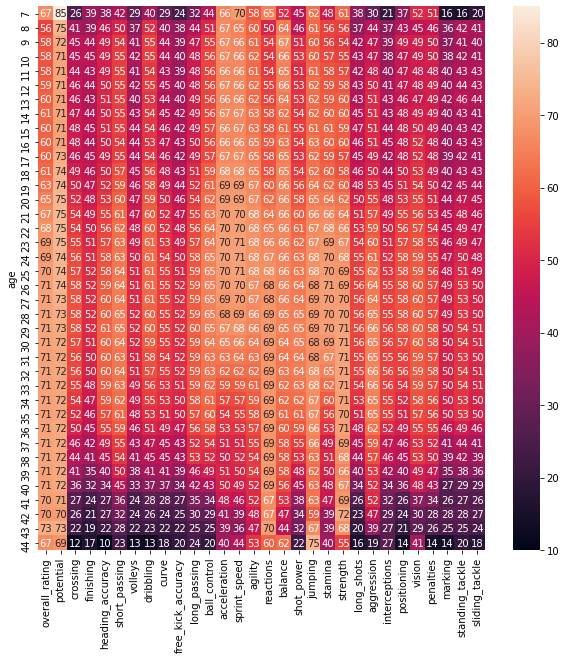

```python
plt.figure(figsize=(10,10))
sns.heatmap(stats_by_age,annot=True)
```

let's explore what attributes deteriorate the most by age

```python
stats_by_age.pct_change(axis=0).sum(axis=0).sort_values()
```

```
penalties            -1.068385
heading_accuracy     -0.982677
dribbling            -0.892976
positioning          -0.801860
finishing            -0.742180
long_shots           -0.740119
ball_control         -0.697035
shot_power           -0.607098
volleys              -0.580904
short_passing        -0.497840
acceleration         -0.481051
sprint_speed         -0.408059
crossing             -0.385573
curve                -0.325656
potential            -0.195881
long_passing         -0.193278
stamina              -0.137742
aggression           -0.133230
agility              -0.083293
vision               -0.080608
strength             -0.068600
reactions            -0.029391
free_kick_accuracy    0.006654
overall_rating        0.023936
jumping               0.203318
balance               0.279210
sliding_tackle        0.388271
interceptions         0.488930
marking               0.524926
standing_tackle       1.065003
dtype: float64
```

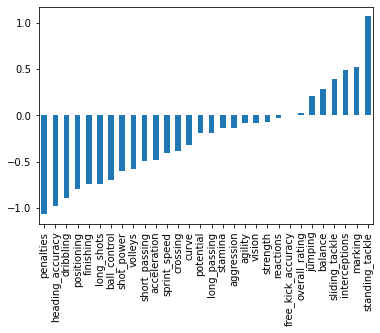

```python
stats_by_age.pct_change(axis=0).sum(axis=0).sort_values().plot(kind='bar')
```

let's expolore at what age the most decline happens

```python
stats_by_age.pct_change(axis=0).sum(axis=1).sort_values()
```

```
age
44   -4.555221
41   -3.798531
40   -2.524013
42   -2.230673
43   -2.225173
39   -1.871991
37   -1.797829
36   -1.031213
38   -0.565582
35   -0.554697
33   -0.524945
34   -0.425383
31   -0.406172
17   -0.356728
```

[output cut: 25 more lines]

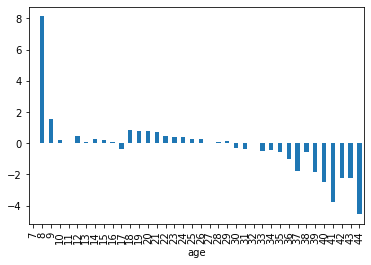

```python
stats_by_age.pct_change(axis=0).sum(axis=1).plot(kind='bar')
```

## Did defensive improvments help teams lose less games at home over the years?

Findings:

1. Teams with most improvements defensively managed to loss less games on average at home Limitations:
2. Lack of information on how these defensive attributes are measured.

## How do players' performance change over time?

Findings:

Limitations:

1. Lack of information on how these attributes are measured

```python
from subprocess import call
call(['python', '-m', 'nbconvert', 'Investigate_a_Dataset.ipynb'])
```

```
1
```